# COMPSCIX 415.2 Homework 4 SOLUTION

Robert Clements

DUE DATE: Feb 27, 2018 @ 6:15PM

# Exercises

## Section 5.6.7: #2, #4, #5 and #6 only

### 2.

The following will work:

```r
library(tidyverse)
library(nycflights13)
not_cancelled <- flights %>%
  filter(!is.na(dep_delay), !is.na(arr_delay))

not_cancelled %>% group_by(dest) %>% summarize(count_dest = n())
```

| dest | count_dest |
| --- | --- |
| ABQ | 254 |
| ACK | 264 |
| ALB | 418 |
| ANC | 8 |
| ATL | 16837 |
| AUS | 2411 |
| AVL | 261 |
| BDL | 412 |
| BGR | 358 |
| BHM | 269 |

[output cut: 94 more lines]

```r
# equivalent to: not_cancelled %>% count(dest)

not_cancelled %>% group_by(tailnum) %>% summarize(sum_dist = sum(distance, na.rm = TRUE))
```

| tailnum | sum_dist |
| --- | --- |
| D942DN | 3418 |
| N0EGMQ | 239143 |
| N10156 | 109664 |
| N102UW | 25722 |
| N103US | 24619 |
| N104UW | 24616 |
| N10575 | 139903 |
| N105UW | 23618 |
| N107US | 21677 |
| N108UW | 32070 |

[output cut: 4027 more lines]

```r
# equivalent to: not_cancelled %>% count(tailnum, wt = distance)
```

### 4.

From the plots below we see that there does seem to be an up and down pattern in the number of cancelled flights per day. Also, there is a positive relationship in the proportion of cancelled flights per day and the average departure delay each day.

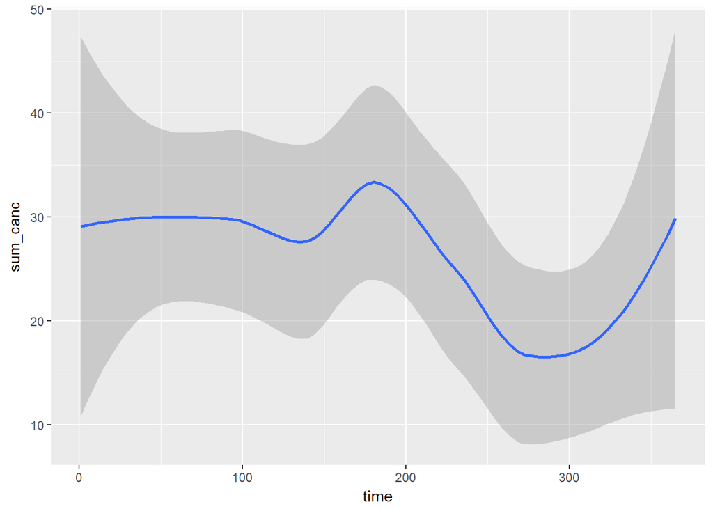

```r
flights <- flights %>%
  mutate(cancelled = is.na(dep_delay) | is.na(arr_delay))

# summarize flights, grouped by day of the year, to get number of cancelled flights, proportion of cancelled flights and average departure delay
summ_flts <- flights %>% group_by(year, month, day) %>% summarize(sum_canc = sum(cancelled, na.rm = TRUE), prop_canc = mean(cancelled, na.rm = TRUE), avg_delay = mean(dep_delay, na.rm = TRUE))

# we can choose to plot the number of cancelled flights over time to look for a pattern since
# it is difficult to see a pattern in the raw numbers
# a smooth line will look best, but first we need to create a new time column. I'm
# keeping it simple here and just creating a new column from 1 through number of days. This
# obviously won't work if we don't have consecutive days, but it works fine for our purposes.
summ_flts <- summ_flts %>% ungroup() %>% mutate(time = 1:n())
summ_flts %>% ggplot() + geom_smooth(aes(x = time, y = sum_canc))
```

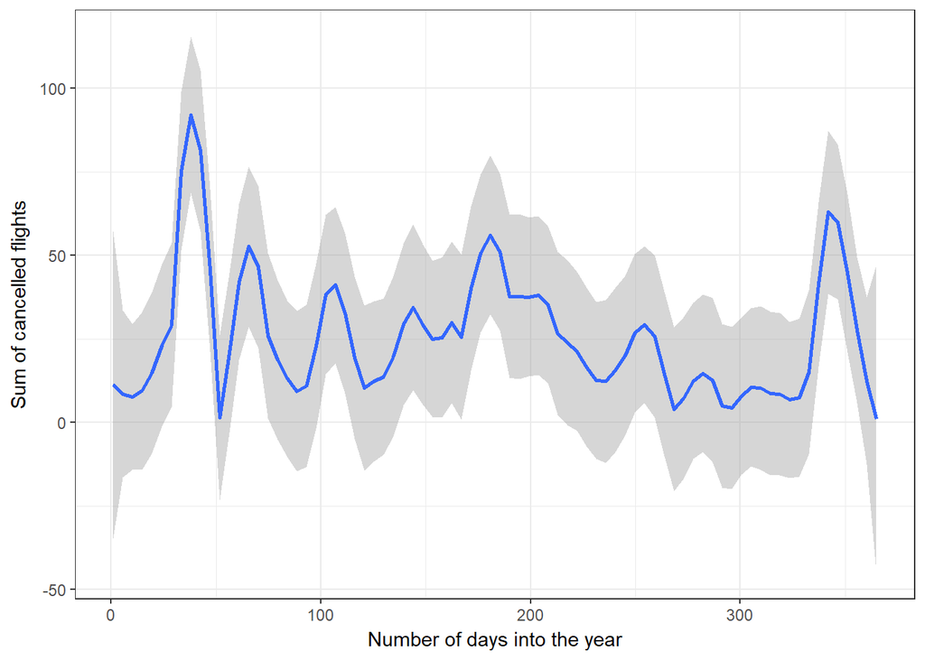

```r
# first plot isn't helpful, so let's play with the span argument
summ_flts %>% ggplot() + geom_smooth(aes(x = time, y = sum_canc), span = .1) +
  xlab('Number of days into the year') +
  ylab('Sum of cancelled flights') +
  theme_bw()
```

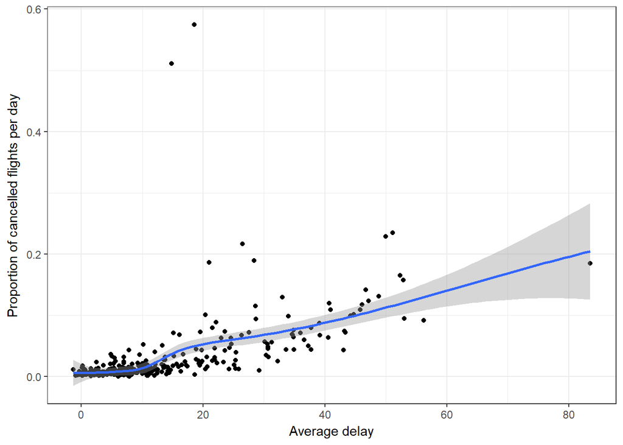

```r
# now let's see if there's a relationship between proportion of cancelled flights and avg delay
summ_flts %>% ggplot(aes(x = avg_delay, prop_canc)) +
  geom_point() +
  geom_smooth() +
  xlab('Average delay') +
  ylab('Proportion of cancelled flights per day') +
  theme_bw()
```

### 5.

We can define “worst” delays in many ways (and you are free to look at several different approaches), but for our purposes let’s start by looking at the median delay time only.

```r
flights %>% group_by(carrier) %>% summarise(med_del = median(dep_delay, na.rm = TRUE)) %>%
  arrange(desc(med_del))
```

| carrier | med_del |
| --- | --- |
| FL | 1.0 |
| WN | 1.0 |
| F9 | 0.5 |
| UA | 0.0 |
| VX | 0.0 |
| B6 | -1.0 |
| EV | -1.0 |
| 9E | -2.0 |
| DL | -2.0 |
| YV | -2.0 |

[output cut: 6 more lines]

What happens if we use the average?

```r
flights %>% group_by(carrier) %>% summarise(mean_del = mean(dep_delay, na.rm = TRUE)) %>%
  arrange(desc(mean_del))
```

| carrier | mean_del |
| --- | --- |
| F9 | 20.215543 |
| EV | 19.955390 |
| YV | 18.996330 |
| FL | 18.726075 |
| WN | 17.711744 |
| 9E | 16.725769 |
| B6 | 13.022522 |
| VX | 12.869421 |
| OO | 12.586207 |
| UA | 12.106073 |

[output cut: 6 more lines]

Median delay time isn’t helpful, and the average delay time reveals F9 to be the worst, but I’m suspicious of outliers.

Let’s look at the *number* of delayed (arrivals OR departure) flights that were delayed for more than 10 minutes. We see below that ExpressJet Airlines has the most delays by pure volume. We could also look at proportions, but you get the idea.

```r
flights %>% filter(dep_delay > 10 | arr_delay > 10) %>%
  count(carrier, sort = TRUE) %>%
  head(10)
```

| carrier | n |
| --- | --- |
| EV | 20689 |
| UA | 19655 |
| B6 | 19255 |
| DL | 13195 |
| MQ | 8891 |
| AA | 8668 |
| 9E | 6079 |
| US | 4940 |
| WN | 4662 |
| VX | 1499 |

There may also be airports that are generally “bad” airports to fly into, which will cause both arrival and departure delays to and from that airport. Again, let’s simply look at volume of delays (we’ll just look at arrival delays and destination airports) where the delay was more than 10 minutes.

Let’s focus on our worst carriers: EV; UA; and B6. Here, we take our three worst carriers in terms of volume of delayed flights, and then plot the proportion of delayed flights for each destination. If the delays are concentrated at a few airports, this may say something more about the airport than the carrier.

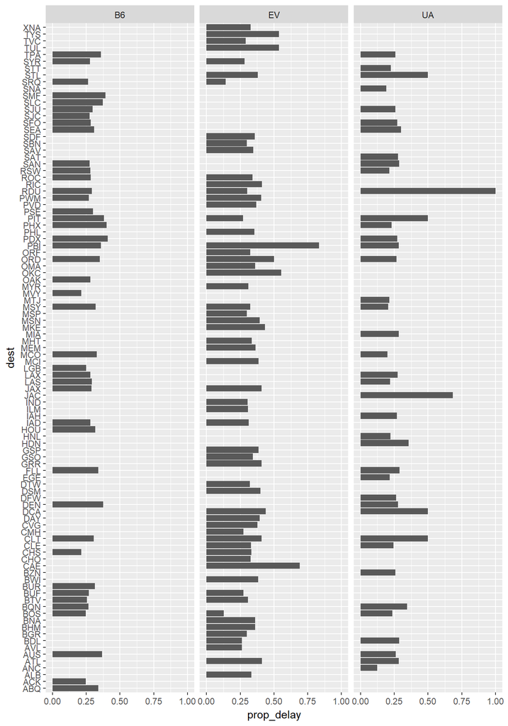

```r
flights %>% filter(carrier %in% c('EV', 'UA', 'B6')) %>%
  mutate(delayed = arr_delay > 10) %>%
  group_by(dest, carrier) %>%
  summarise(prop_delay = mean(delayed, na.rm = TRUE)) %>%
  ggplot(aes(x = dest, y = prop_delay)) +
  geom_bar(stat = 'identity') +
  coord_flip() +
  facet_wrap(~carrier)
```

We can see that for these carriers, they seem to have a high proportion of delayed flights across a wide range of desinations - so it is likely the carrier, rather than the airport, that is the problem.

### 6.

The `sort` argument sorts the output of `count` in descending order of the count. This is useful anytime you want to see which groups are the most populated.

## Section 10.5: #1, #2, #3 and #6 only

### 1.

There are a few ways to tell if an object is a tibble. You can use the `class` function. You can also print the output of the object, which will output a truncated display of the data (only the columns and a subset of the rows that can fit on the screen) as well as display the column *types*.

### 2.

From the code below we see that tibbles require the full column name when subsetting, whereas data frames allow partial matching. For tibbles, subsetting a single column with `[, "column_name"]` will return a tibble, whereas data frames return vectors. If you want to return a vector with a tibble you must use `$` or `[[]]`.

The defaults for data frames can be frustrating if you want to return the same object (even if it is just a single column). Also, it is definitely not advised that your code should have partial matching of names. This is prone to error, and poor formatting.

```r
df <- data.frame(abc = 1, xyz = "a")
df$x
```

```
## [1] a
## Levels: a
```

```r
df[, "xyz"]
```

```
## [1] a
## Levels: a
```

```r
df[, c("abc", "xyz")]
```

| abc | xyz |
| --- | --- |
| 1 | a |

```r
tb <- as_tibble(df)
tb$x
```

[output not shown]

```r
tb[, "xyz"]
```

| xyz |
| --- |
| a |

```r
tb[, c("abc", "xyz")]
```

| abc | xyz |
| --- | --- |
| 1 | a |

### 3.

Like this:

```r
var <- "mpg"
mtcars[[var]]
```

```
##  [1] 21.0 21.0 22.8 21.4 18.7 18.1 14.3 24.4 22.8 19.2 17.8 16.4 17.3 15.2
## [15] 10.4 10.4 14.7 32.4 30.4 33.9 21.5 15.5 15.2 13.3 19.2 27.3 26.0 30.4
## [29] 15.8 19.7 15.0 21.4
```

### 6.

The `n_extra` argument allows you to select the number of extra columns to print.

## Section 12.3.3: #2, #3 and #4 only

### 2.

The variable names are non-sytactic names, meaning that they start with a number, so they have to be surrounded with tick marks.

```r
table4a %>%
 gather(1999, 2000, key = "year", value = "cases")
```

```
## Error in inds_combine(.vars, ind_list): Position must be between 0 and n
```

```r
table4a %>%
  gather(`1999`, `2000`, key = "year", value = "cases")
```

| country | year | cases |
| --- | --- | --- |
| Afghanistan | 1999 | 745 |
| Brazil | 1999 | 37737 |
| China | 1999 | 212258 |
| Afghanistan | 2000 | 2666 |
| Brazil | 2000 | 80488 |
| China | 2000 | 213766 |

### 3.

The error message tells us that the reason it won’t spread is because we have duplicate identifiers, meaning we have the same `name` and `key` showing up multiple times. We can add an extra column, such as year, to fix this problem. See below.

```r
people <- tribble(
  ~name,             ~key,    ~value,
  #-----------------|--------|------
  "Phillip Woods",   "age",       45,
  "Phillip Woods",   "height",   186,
  "Phillip Woods",   "age",       50,
  "Jessica Cordero", "age",       37,
  "Jessica Cordero", "height",   156
)
# results in an error
spread(people, key = key, value = value)
```

```
## Error: Duplicate identifiers for rows (1, 3)
```

```r
people <- tribble(
  ~name,            ~year, ~key,    ~value,
  #-----------------|--------|------
  "Phillip Woods", 2010,   "age",       45,
  "Phillip Woods", 2010,   "height",   186,
  "Phillip Woods", 2015,   "age",       50,
  "Jessica Cordero", 2010,  "age",       37,
  "Jessica Cordero", 2010, "height",   156
)
spread(people, key = key, value = value)
```

| name | year | age | height |
| --- | --- | --- | --- |
| Jessica Cordero | 2010 | 37 | 156 |
| Phillip Woods | 2010 | 45 | 186 |
| Phillip Woods | 2015 | 50 | NA |

### 4.

```r
preg <- tribble(
  ~pregnant, ~male, ~female,
  "yes",     NA,    10,
  "no",      20,    12
)
preg %>% gather(male, female, key = gender, value = who_knows)
```

| pregnant | gender | who_knows |
| --- | --- | --- |
| yes | male | NA |
| no | male | 20 |
| yes | female | 10 |
| no | female | 12 |

## Section 12.4.3: #1 and #2 only

### 1.

`extra` controls what happens if there are too many pieces to separate, while `fill` controls what happens when there are not enough pieces to separate.

For `extra` there are essentially two options: dropping the extra pieces (with or without a warning) or merging extra pieces together, and this is illustrated below.

For `fill` there are also essentially two options: fill in with missing values from either the left or the right (with or without a warning), and this is illustrated below.

```r
tibble(x = c("a,b,c", "d,e,f,g", "h,i,j")) %>%
  separate(x, c("one", "two", "three"))
```

| one | two | three |
| --- | --- | --- |
| a | b | c |
| d | e | f |
| h | i | j |

```r
tibble(x = c("a,b,c", "d,e,f,g", "h,i,j")) %>%
  separate(x, c("one", "two", "three"), extra = "merge")
```

| one | two | three |
| --- | --- | --- |
| a | b | c |
| d | e | f,g |
| h | i | j |

```r
tibble(x = c("a,b,c", "d,e", "f,g,i")) %>%
  separate(x, c("one", "two", "three"))
```

| one | two | three |
| --- | --- | --- |
| a | b | c |
| d | e | NA |
| f | g | i |

```r
tibble(x = c("a,b,c", "d,e", "f,g,i")) %>%
  separate(x, c("one", "two", "three"), fill = "left")
```

| one | two | three |
| --- | --- | --- |
| a | b | c |
| NA | d | e |
| f | g | i |

### 2.

The `remove` option will remove the original columns from your data set after they have been united or separated. You may want to set this to `FALSE` when you are doing exploration of the data and want to keep all original content or do some QC of your work.

Answer these questions:

Follow these steps:  
- Download the baby_names.txt file from Canvas which is in the Homework 4 assignment section.  
- Load this file into R *correctly* and take a glimpse of the output.  
- Export this file as an rds file and call it ‘baby_names.rds’.  
- Reload the baby_names.rds file and take another glimpse.  
- **Show all of your code and the output.** There should be two data import lines of code, one data export line of code, and two glimpses of the data.

```r
baby_names <- read_delim('baby_names.txt', delim = '|')
glimpse(baby_names)
```

```
## Observations: 30,000
## Variables: 5
## $ year <int> 1880, 1880, 1880, 1880, 1880, 1880, 1880, 1880, 1880, 188...
## $ sex  <chr> "F", "F", "F", "F", "F", "F", "F", "F", "F", "F", "F", "F...
## $ name <chr> "Mary", "Anna", "Emma", "Elizabeth", "Minnie", "Margaret"...
## $ n    <int> 7065, 2604, 2003, 1939, 1746, 1578, 1472, 1414, 1320, 128...
## $ prop <dbl> 0.072384329, 0.026679234, 0.020521700, 0.019865989, 0.017...
```

```r
saveRDS(baby_names, file = 'baby_names.rds')
baby_names_rds <- readRDS('baby_names.rds')
glimpse(baby_names_rds)
```

```
## Observations: 30,000
## Variables: 5
## $ year <int> 1880, 1880, 1880, 1880, 1880, 1880, 1880, 1880, 1880, 188...
## $ sex  <chr> "F", "F", "F", "F", "F", "F", "F", "F", "F", "F", "F", "F...
## $ name <chr> "Mary", "Anna", "Emma", "Elizabeth", "Minnie", "Margaret"...
## $ n    <int> 7065, 2604, 2003, 1939, 1746, 1578, 1472, 1414, 1320, 128...
## $ prop <dbl> 0.072384329, 0.026679234, 0.020521700, 0.019865989, 0.017...
```